# 3. 线性神经网络

Deep Learning I

3. 线性神经网络

WU Xiaokun 吴晓堃

xkun.wu [at] gmail

2021/03/07

# 线性回归

## 什么是回归？

**回归 regression**

- Galton 发现父亲的身高和儿子的身高之间存在着某种给定的关系
  - “子辈的平均身高是其父辈及其所处族群平均身高的加权平均和”。
  - 差异性？从整个人群上来看，父亲和孩子的身高分布是很相近的。
- 统计数据**驱向均值**的现象
  - `re-`：重复；`gress`：行走；`-sion`：名词化
  - 多次模拟考试成绩的均值可以作为真实水准的依据

## 为什么讨论回归？

**回归分析**：对自变量和因变量之间的关系建模

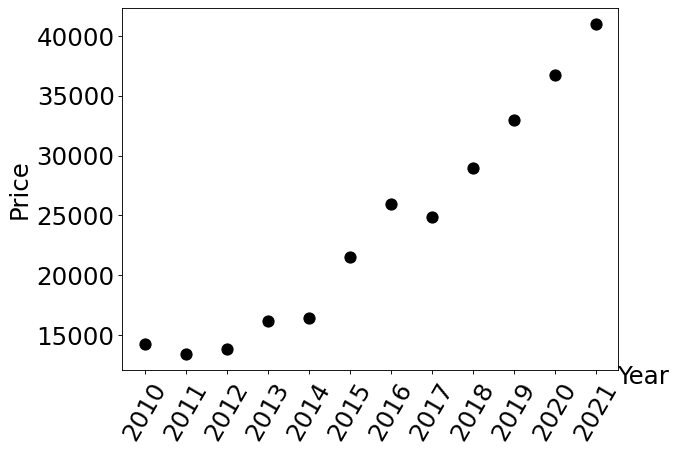

- 用于预测：源于**对趋势（主观判断）的信念**
  - 统计学信条：“相关性并不意味着因果关系”
  - 推断：人脑对客观规律的简化描述

## 线性假设

购房时需要对其价值进行评估

- 找出几个**关键因素**，如面积，地段，存款等
- 做最简单的线性假设：固定比率变化
  - 人脑不善于做非线性计算

**线性模型**：$y = w_1x_1 + w_2x_2 + .. + w_dx_d + b$

- 任务：预测房价
  - 特征：自变量，相关的一些因素
  - 权重：对应自变量的影响力
  - 偏置：基准值，如当年均值

## 线性回归问题

假如能够确定参数$\mathbf{w}, b$：

$$\hat{y} = \mathbf{w}^T \mathbf{x} + b$$

问题转化：如何确定参数$\mathbf{w}, b$？

**基本假设**：

- 自变量和因变量线性相关
- 噪音符合正态分布

## 数据驱动

收集样本数据

- **样本**：可观测的数据对$(\mathbf{x}, y)$
  - **样本-特征存储（矩阵）**：每一行是一个样本

$$\mathbf{y} = \mathbf{X} \mathbf{w} + b, \mathbf{X} \in \mathbb{R}^{N
\times d}$$

两种求解思路：

- **显式解**：$\mathbf{\bar{w}}^* = (\mathbf{\bar{X}}^T\mathbf{\bar{X}})^{-1}\mathbf{\bar{X}}^T\mathbf{y}$
  - 只适用于有解析解的简单问题
  - 满秩：数据之间不能有相关性
- **数值优化**

## 优化问题定义

定义损失函数，如**平方损失**：$l(y,\hat{y}) = \frac{1}{2} (y-\hat{y})^2$

- 但不可能每个点都最优：“按下葫芦浮起瓢”

**优化目标**：$\mathcal{L}(\mathbf{X},\mathbf{y};\mathbf{w},b) = \frac{1}{2N} \lVert \mathbf{y} - \mathbf{X} \mathbf{w} - b \rVert^2$

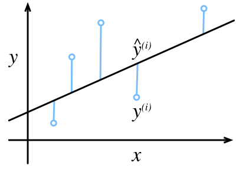

**优化问题**：$\mathbf{w}^*,b^* = \argmin_{\mathbf{w},b} \mathcal{L}(\mathbf{X},\mathbf{y};\mathbf{w},b)$

## 梯度下降法求解

1. 初始化参数：$\mathbf{w} = \mathbf{w_0}$
2. 循环：
   1. 计算当前梯度：$\frac{\partial \mathcal{L}}{\partial \mathbf{w}}|_{\mathbf{w}}$
   2. 更新参数：$\mathbf{w} = \mathbf{w} - \eta \frac{\partial \mathcal{L}}{\partial \mathbf{w}}|_{\mathbf{w}}$

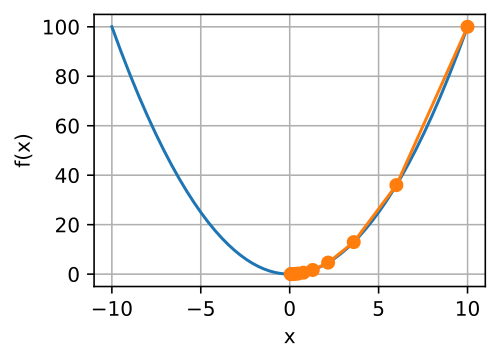

## 小批量随机梯度下降

数据量太大怎么办？

- 计算复杂度：损失值、梯度值都是$O(n)$
- 空间复杂度：内存、显存放不下

**随机梯度下降（SGD）**：每次迭代对训练数据随机均匀采样

- 近似计算梯度：$\widehat{\nabla f} = \frac{1}{B} \sum_{i=1}^B \nabla f_i$
- $B$称为批量大小

思考：随机梯度是对完整梯度的**无偏估计**

- 提示：计算数学期望

## 选择批量大小

不能太大

- 内存消耗增加
- 容易陷入**极小值**：批量之间的差异不足
  - 极小值附近地形比较平坦
- 最大可以和数据集大小相同

不能太小

- 不利于**并行计算**
- 但在线应用时可能为1

确定批量大小：主要靠**经验估计**

- 显存能够容纳的最大值
- 二分搜索算法

## 线性回归可以看成单层神经网络

$$y = w_1x_1 + w_2x_2 + .. + w_dx_d +
b$$

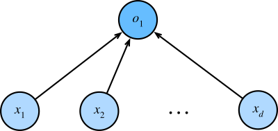

注意：不存在线性的多层神经网络！

# 实验：线性回归的从零开始实现

## 人造数据集

带噪音的人造数据

$$\mathbf{y} = \mathbf{X} \mathbf{w} + b + \epsilon$$

# 实验：线性回归的简洁实现

# 作业：线性回归模型

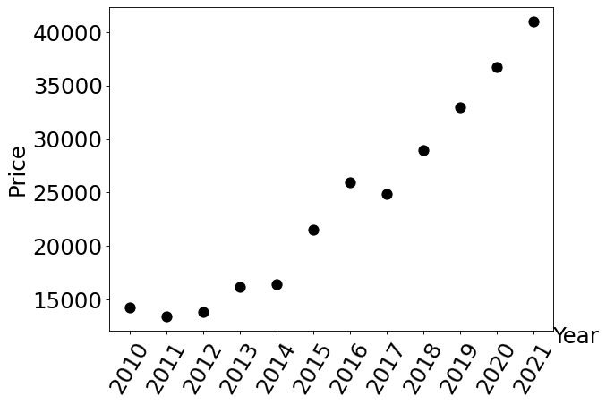

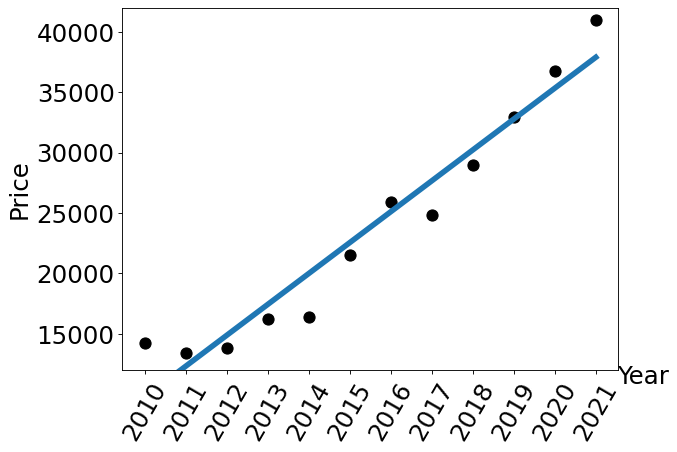

# Halftime

# softmax回归

## 回归、分类

**回归**：输出连续数值

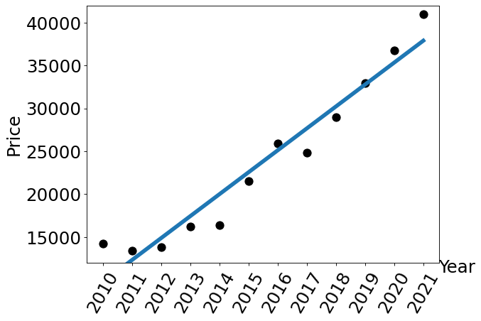

**分类**：输出离散类别

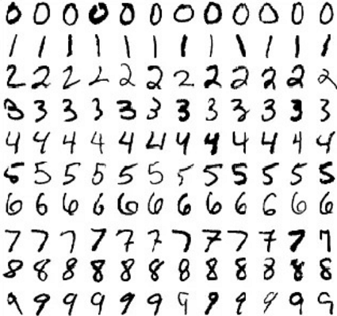

## 回归用于分类

根据**取值范围**分类

- 例如$[0, 10)$的坐标区间：$[0, 1)$代表第一个类

问题：不容易度量

- 目标：同类尽量聚在一起；**异类尽量分散开**
  - 边界附近很难区分
- 如何构造目标（损失）函数？
  - 连续值，却聚在几个点附近

## 从回归到多类分类

回归

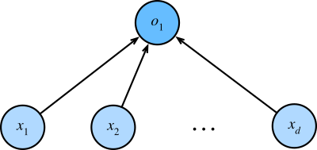

- 输出单个连续值
  - 输出：预测值
- 误差：输出与真实值的差别

分类

- 输出多个不同的连续值
  - 每个输出：预测类别的**可信程度**
- 误差：输出与真实概率的差别

问题：

- 如何从输出的多个实数值构造概率？
- 如何表达“真实概率”？
- 如何计算概率之间的差别？

## 独热编码

**独热编码 one-hot encoding**：单有效位编码的向量

- $y = [y_1, y_2, .., y_C]$
- $C$个类；$y_c = 1$表示正确类别是$c$

例如数字$3$的编码：

- $[0, 0, 0, 1, 0, 0, 0, 0, 0, 0]$
- $C = 10, c = 3$

## softmax运算

输出向量：$\mathbf{o} = [o_1, o_2, .., o_C]^T$

- 需要计算**每个分量的比重**

$$\hat{\mathbf{y}} = \text{softmax}(\mathbf{o}), \hat{y}_j =
\frac{\exp(o_j)}{\sum_k \exp(o_k)}$$

- softmax本质上是**归一化**
  - $0 \le \hat{y}_j \le 1$，并且 $\sum_j \hat{y}_j = 1$

## 小批量样本

假设批量大小为$B$，特征维度为$d$

$$\mathbf{O} = \mathbf{X}\mathbf{W} + \mathbf{b}\\
\hat{\mathbf{Y}} = \text{softmax}(\mathbf{O})\\$$

- $\mathbf{X} \in \mathbb{R}^{B \times d}, \mathbf{W} \in \mathbb{R}^{d \times C}, \mathbf{b} \in \mathbb{R}^{1 \times C}$

问题：如何计算误差（损失值）？

## 度量概率相似程度

度量概率分布相似程度：采样点上的**重合度**

$$\lVert \mathbf{y}, \hat{\mathbf{y}} \rVert \propto \prod_c
\hat{y}_c^{y_c}\\$$

- 唯一的$y_c = 1$对应的$\hat{y}_c$被选出来
- 数值上与**内积**相同

问题：大量概率值的乘积导致下溢？

## 对数似然

取负对数得到损失函数：

$$\begin{aligned}
l(\mathbf{y}, \hat{\mathbf{y}}) &= - \log \prod_c \hat{y}_c^{y_c}\\
&= - \sum_c y_c \log \hat{y}_c\\
\end{aligned}$$

- 常用数学技巧。
  - 注意：取对数**不改变序关系**
- 数值计算：加法总是比乘法好

## 信息论解释

在信息论中，**熵 entropy**用于度量数据中的信息量

$$H(\mathbf{P}) = - \sum_i \mathbf{P}_i \log \mathbf{P}_i\\$$

对从分布 $\mathbf{P}$ 中随机抽样的数据编码，至少需要 $H[\mathbf{P}]$ “**纳特 nat**”。

- $1\ \text{nat} = \log(2)^{-1} \approx 1.44\ \text{bit}$

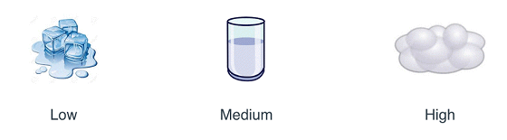

## 熵的理解

想象从盒子里抽奖

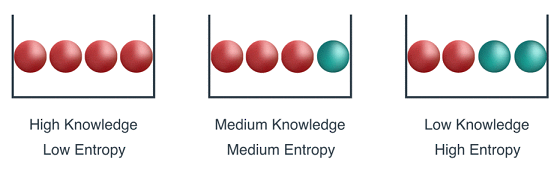

- 熵可以理解为：对数据流进行连续预测的**预期“惊异”**

## 交叉熵

**交叉熵 cross entropy**用于度量两个概率分布的差异

$$H(\mathbf{P}, \mathbf{Q}) = - \sum_i P_i \log Q_i\\$$

- 即前面损失函数的定义
  - 损失函数：$- \sum_c y_c \log \hat{y}_c$
  - 预测是$\mathbf{Q}$，但实际是$\mathbf{P}$

数学上漂亮：梯度是预测与真实概率的差值

- $\frac{\partial}{\partial o_i} l(\mathbf{y}, \hat{\mathbf{y}}) = \text{softmax}(\mathbf{o})_i - y_i = \hat{y}_i - y_i$

# 实验：图像分类数据集

## 实际工程问题不是数学题

解决工程问题的思路需要考虑实际情况

- 人造数据：训练出来的模型**只能拟合给定的数据**

优化目标：保证理论上参数对训练数据是最优的

- 实际应用：通常是**完全不同**的数据

## 训练集、测试集

**测试集**：实际应用时才能拿到的数据

- 对于训练过程来说是**未知**的

类比：训练集=日常习题；测试集=考试题

- 训练参数：通过习题掌握**解题思路**

模拟实际应用：将数据划分成两部分

- 对比：全部数据当成训练集

# 实验：softmax回归的从零开始实现

# 实验：softmax回归的简洁实现

# 课程项目：手写数字分类

## MNIST 数据集

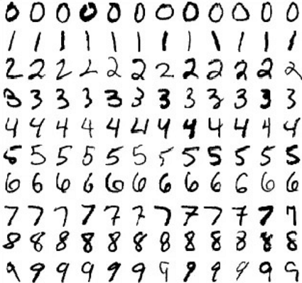

# Review

## 本章内容

线性回归模型。实验：线性回归的实现。softmax回归模型。实验：softmax回归的实现

**重点**：线性模型；线性回归的实现；softmax模型；softmax回归的实现

**难点**：交叉熵。

## 学习目标

- 理解线性回归模型的一般形式、损失函数、优化算法。
- 掌握使用线性回归解决预测问题的实现方法。
- 理解选取批量大小的注意事项。
- 理解分类问题中softmax运算的作用。
- 理解softmax回归模型的一般形式、损失函数、优化算法。
- 掌握使用softmax回归解决分类问题的实现方法。
- 了解信息论中交叉熵的作用。

## 问题

(*) 假设$\mathbf{y} = \mathbf{X} \mathbf{w}, \mathbf{X} \in \mathbb{R}^{N \times d}, \mathbf{w} \in \mathbb{R}^{d \times 1}$，求参数$\mathbf{w}$的解析解。

假设$\mathbf{y} = \mathbf{X} \mathbf{w}, \mathbf{X} \in \mathbb{R}^{N \times d}, \mathbf{w} \in \mathbb{R}^{d \times 1}$，简述随机梯度下降法对参数$\mathbf{w}$的求解算法。

简述选取批量大小的注意事项。

简述分类问题中softmax运算的作用。

简述独热 one-hot 编码在分类问题中的应用。

简述分类问题中损失函数的构造方法，及其计算方法。

(*) 简述信息论中交叉熵的作用，及其在分类问题中的应用。